# 1.Import neccessary libaries nedded

```python
import numpy as np
import pandas as pd
import matplotlib.pyplot as plt
import seaborn as sns
```

```python
print(sns.get_dataset_names())
```

```
['anagrams', 'anscombe', 'attention', 'brain_networks', 'car_crashes', 'diamonds', 'dots', 'dowjones', 'exercise', 'flights', 'fmri', 'geyser', 'glue', 'healthexp', 'iris', 'mpg', 'penguins', 'planets', 'seaice', 'taxis', 'tips', 'titanic']
```

## 2.**Loading** **Dataset**

```python
df=sns.load_dataset('car_crashes')
```

```python
df.info()
```

```
<class 'pandas.core.frame.DataFrame'>
RangeIndex: 51 entries, 0 to 50
Data columns (total 8 columns):
 #   Column          Non-Null Count  Dtype
---  ------          --------------  -----
 0   total           51 non-null     float64
 1   speeding        51 non-null     float64
 2   alcohol         51 non-null     float64
 3   not_distracted  51 non-null     float64
 4   no_previous     51 non-null     float64
 5   ins_premium     51 non-null     float64
 6   ins_losses      51 non-null     float64
 7   abbrev          51 non-null     object
dtypes: float64(7), object(1)
memory usage: 3.3+ KB
```

```python
df.shape
```

```
(51, 8)
```

```python
df.head(5)
```

|  | total | speeding | alcohol | not_distracted | no_previous | ins_premium | ins_losses | abbrev |
| --- | --- | --- | --- | --- | --- | --- | --- | --- |
| 0 | 18.8 | 7.332 | 5.640 | 18.048 | 15.040 | 784.55 | 145.08 | AL |
| 1 | 18.1 | 7.421 | 4.525 | 16.290 | 17.014 | 1053.48 | 133.93 | AK |
| 2 | 18.6 | 6.510 | 5.208 | 15.624 | 17.856 | 899.47 | 110.35 | AZ |
| 3 | 22.4 | 4.032 | 5.824 | 21.056 | 21.280 | 827.34 | 142.39 | AR |
| 4 | 12.0 | 4.200 | 3.360 | 10.920 | 10.680 | 878.41 | 165.63 | CA |

## plotting univariate distribution

```python
df.describe()
```

|  | total | speeding | alcohol | not_distracted | no_previous | ins_premium | ins_losses |
| --- | --- | --- | --- | --- | --- | --- | --- |
| count | 51.000000 | 51.000000 | 51.000000 | 51.000000 | 51.000000 | 51.000000 | 51.000000 |
| mean | 15.790196 | 4.998196 | 4.886784 | 13.573176 | 14.004882 | 886.957647 | 134.493137 |
| std | 4.122002 | 2.017747 | 1.729133 | 4.508977 | 3.764672 | 178.296285 | 24.835922 |
| min | 5.900000 | 1.792000 | 1.593000 | 1.760000 | 5.900000 | 641.960000 | 82.750000 |
| 25% | 12.750000 | 3.766500 | 3.894000 | 10.478000 | 11.348000 | 768.430000 | 114.645000 |
| 50% | 15.600000 | 4.608000 | 4.554000 | 13.857000 | 13.775000 | 858.970000 | 136.050000 |
| 75% | 18.500000 | 6.439000 | 5.604000 | 16.140000 | 16.755000 | 1007.945000 | 151.870000 |
| max | 23.900000 | 9.450000 | 10.038000 | 23.661000 | 21.280000 | 1301.520000 | 194.780000 |

Inference: it shows how many accidents took per quantile and also shows standard deviation,mean,max

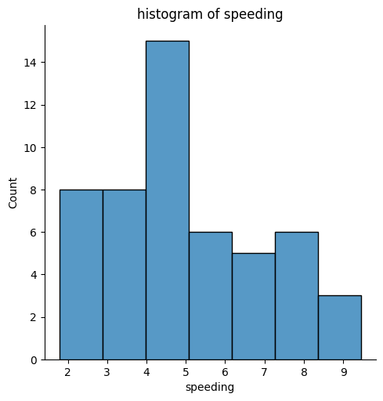

```python
#histogram
sns.displot(df['speeding'])
plt.title("histogram of speeding")
plt.show()
```

Inference: speeding ranges 4 to 5 has more count

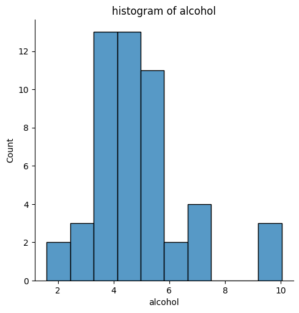

```python
sns.displot(df['alcohol'])
plt.title("histogram of alcohol")
plt.show()
```

Inference:alcohol range from 4 to 5 hs highest count

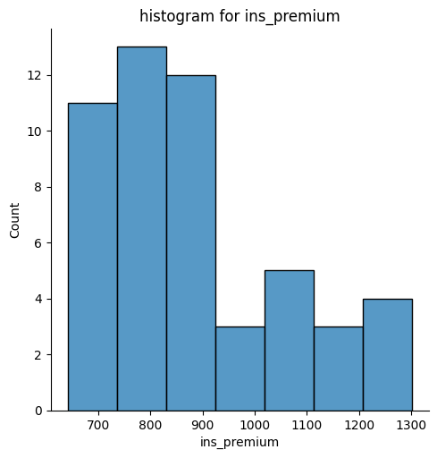

```python
sns.displot(df['ins_premium'])
plt.title("histogram for ins_premium")
plt.show()
```

Inference:car ins_premium has highest count at 800

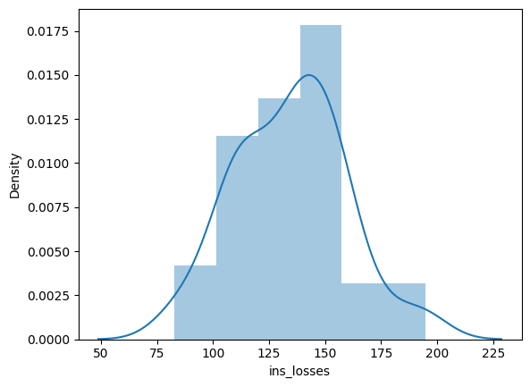

```python
sns.distplot(df["ins_losses"])
```

Inference: Losses incurred by insurance companies for collisions per insured driver occurs mostly at 150

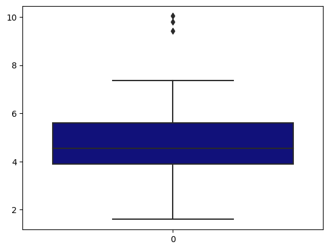

```python
sns.boxplot(df['alcohol'],color='darkblue')
```

Inference: it shows the descriptive statistics in order to detect the outliers which is used further for data preprocessing .This represent the 5 point statistics in a graphical manner

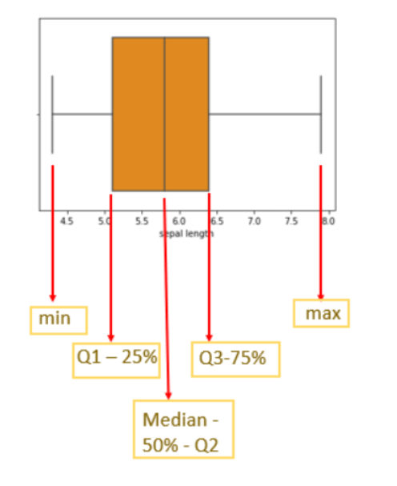

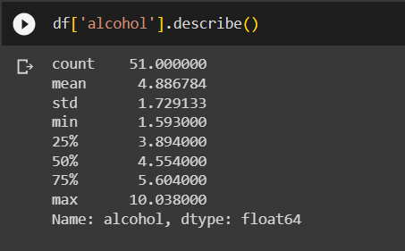

### **Bivariate** **distribution**

# Bar **Plot**

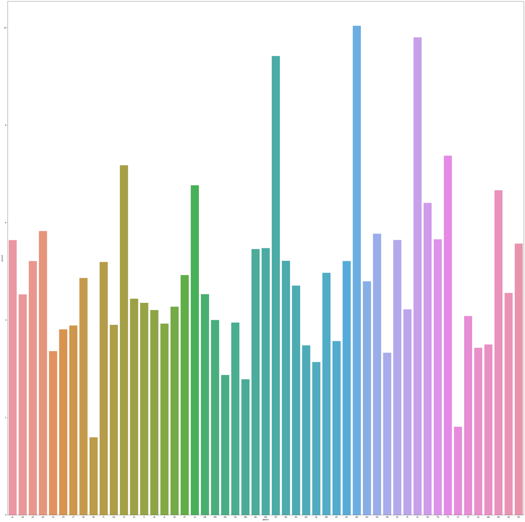

```python
fig, ax1 = plt.subplots(figsize=(50, 50))
sns.barplot(x="abbrev",y="alcohol",data=df, ax=ax1)
plt.show()
```

Inference:number of crashes that happened due to Alcohol intake is the highest in the country ND (North Dakota)

# **Scatter** **plot**

numerical vs numerical

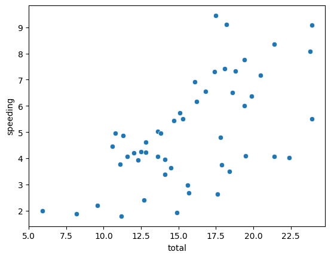

```python
sns.scatterplot(x="total",y="speeding",data=df)
```

Inference:from the plot we can say that as speeding increases total car_crashes accident increases and on an avergae accidents were ocuuring at positionn between 4 to 7

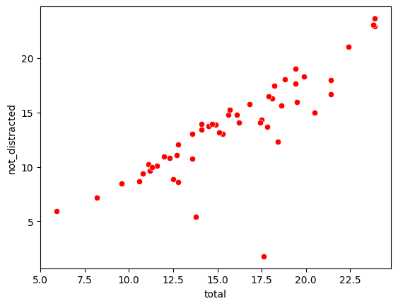

```python
sns.scatterplot(x="total",y="not_distracted",data=df,color="red")
```

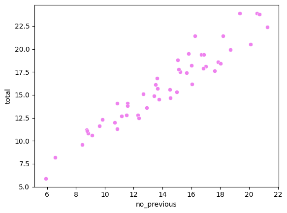

```python
sns.scatterplot(x="no_previous",y="total",data=df,color="violet")
```

Inference: we can conclude that as total accidents and no_previous increases propotionally which shows positive relationship. it is possible to find a line of best fit

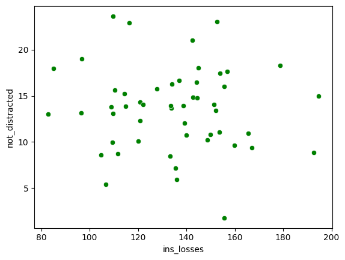

```python
sns.scatterplot(x="ins_losses",y="not_distracted",data=df,color="green")
```

## **Line** **plot**

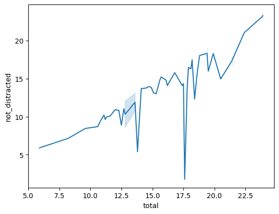

```python
sns.lineplot(x="total",y="not_distracted",data=df)
```

Inference: it can be inferenced that even though it has ups and downs, total number of crashes happened vs crashes happened even with drivers no distracted graph is increasing graph .